## Title: Analysis of Heart Disease Risk Factors Dataset

## Author: "Mohammad Hajjaj"

## Date: 2024-07-29

# 1) Introduction :

Heart disease remains a predominant cause of illness and death globally. Recognizing the risk factors associated with heart disease is crucial for early detection, prevention, and management. This study uses a dataset from Kaggle, containing demographic, lifestyle, and medical information, to explore and analyze the factors contributing to heart disease. By examining these variables, we aim to identify significant predictors and understand their interactions, thereby enhancing clinical decision-making and patient outcomes.

# 2) Dataset Description :

## 2.1. Source of the Dataset.

The dataset utilized in this analysis is an open-source resource available on Kaggle. It is designed to assist researchers and clinicians in understanding heart disease risk factors. This dataset provides comprehensive information on individuals, including demographic details, lifestyle habits, medical history, and symptoms associated with heart disease.

## 2.2 Columns and Variables:

The dataset includes the following variables:

- Age: Age of the individual (years).
- Gender: Gender of the individual (Male/Female).
- Cholesterol: Cholesterol level in mg/dL.
- Blood Pressure: Systolic blood pressure in mmHg.
- Heart Rate: Heart rate in beats per minute.
- Smoking: Smoking status (Never/Former/Current).
- Alcohol Intake: Alcohol intake frequency (None/Moderate/Heavy).
- Exercise Hours: Hours of exercise per week.
- Family History: Family history of heart disease (Yes/No).
- Diabetes: Diabetes status (Yes/No).
- Obesity: Obesity status (Yes/No).
- Stress Level: Stress level on a scale of 1 to 10.
- Blood Sugar: Fasting blood sugar level in mg/dL.
- Exercise Induced Angina: Presence of exercise-induced angina (Yes/No).
- Chest Pain Type: Type of chest pain experienced (Typical Angina/Atypical Angina/Non-anginal Pain/Asymptomatic).
- Heart Disease: Target variable indicating the presence of heart disease (0: No, 1: Yes).

# 3) Literature Summary:

Extensive research has been conducted to understand the various risk factors contributing to heart disease. Demographic factors such as age and gender, lifestyle habits like smoking and alcohol intake, and medical history, including cholesterol levels, blood pressure, and diabetes, are well-documented in the literature as significant contributors to heart disease. Recent advancements in data analysis have enhanced the precision of heart disease prediction models, incorporating machine learning techniques and large datasets to provide deeper insights into risk factors and their interactions.

## 4) Research Questions:

Can we accurately predict risk of heart attack using patients' demographics, comorbidities, and other life style factors?

# 5) Unmet Clinical Need:

Despite the wealth of information available, there remains a critical need for comprehensive models that integrate various risk factors to predict heart disease accurately. Identifying the most significant predictors and understanding their interactions can aid in developing better prevention strategies and personalized treatment plans, ultimately reducing the burden of heart disease.

# 6) Data Analysis Steps:

We are going to perform the folloing steps to adress this resarche Qusition:

1. Exploratory Data Analysis (EDA): Visualize relationships between variables and the target.
2. Descriptive Statistics: Summarize the key characteristics of the dataset.
3. Data Cleaning: Handle missing values, outliers, and ensure data consistency.
4. Model Building: Develop predictive models using techniques such as logistic regression Naive Bayes,,SVMs Decision Tree, Random Forest, Neural Network..
5. Model Evaluation: Assess model performance using metrics like accuracy, precision, recall, a d AUC-R and the Lift Curve.C.

```python
%matplotlib inline
import pandas as pd
import numpy as np
import matplotlib.pyplot as plt
import seaborn as sns
sns.set(style = "darkgrid")
import random
```

```python
from sklearn.preprocessing import LabelEncoder
from sklearn.model_selection import train_test_split, cross_val_score
from sklearn.preprocessing import StandardScaler
from sklearn.tree import DecisionTreeClassifier
from sklearn.naive_bayes import GaussianNB
from sklearn.ensemble import RandomForestClassifier
from sklearn.ensemble import GradientBoostingClassifier
from sklearn.tree import DecisionTreeClassifier
from sklearn.linear_model import LogisticRegression
from sklearn.neighbors import KNeighborsClassifier
from sklearn.neural_network import MLPClassifier
from sklearn.svm import SVC

#from delong import delong_roc_test

from sklearn.metrics import confusion_matrix, ConfusionMatrixDisplay, classification_report, roc_curve, auc, roc_auc_score
```

```python
df = pd.read_csv('heart_disease_dataset.csv')
```

# 1 Exploratory Data Analysis (EDA):A

## 1.1 Basic EDA

```python
print(df.info())
```

```
<class 'pandas.core.frame.DataFrame'>
RangeIndex: 1000 entries, 0 to 999
Data columns (total 16 columns):
 #   Column                   Non-Null Count  Dtype
---  ------                   --------------  -----
 0   Age                      1000 non-null   int64
 1   Gender                   1000 non-null   object
 2   Cholesterol              1000 non-null   int64
 3   Blood Pressure           1000 non-null   int64
 4   Heart Rate               1000 non-null   int64
 5   Smoking                  1000 non-null   object
 6   Alcohol Intake           660 non-null    object
 7   Exercise Hours           1000 non-null   int64
 8   Family History           1000 non-null   object
 9   Diabetes                 1000 non-null   object
 10  Obesity                  1000 non-null   object
 11  Stress Level             1000 non-null   int64
 12  Blood Sugar              1000 non-null   int64
 13  Exercise Induced Angina  1000 non-null   object
 14  Chest Pain Type          1000 non-null   object
 15  Heart Disease            1000 non-null   int64
dtypes: int64(8), object(8)
memory usage: 125.1+ KB
None
```

#### The dataset contains a mix of categorical (object) and continuous (int64) variables. One column, "Alcohol Intake," has missing values, with 660 non-null entries. The total number of entries in each of the other columns is 1000. There are 8 continuous variables and 8 categorical variables in the dataset. The outcome variable is "Heart Disease".

## 1.2 EDA for categorical variables

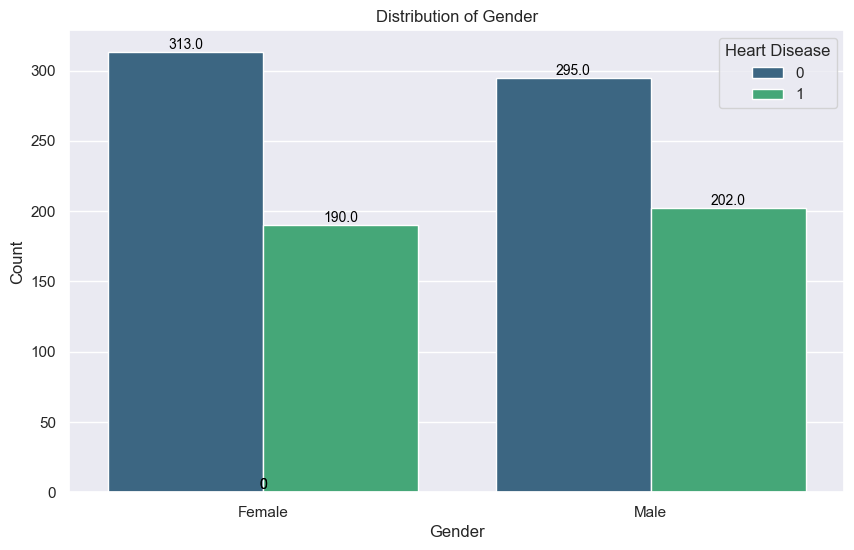

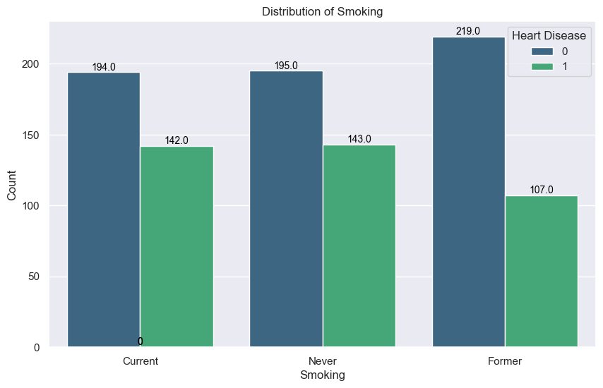

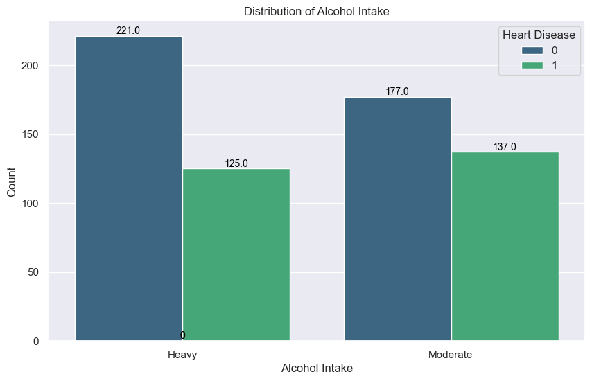

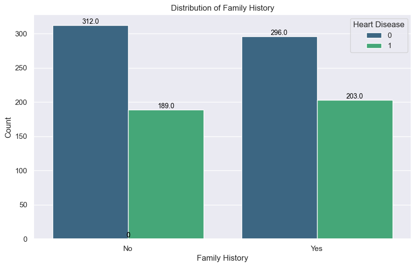

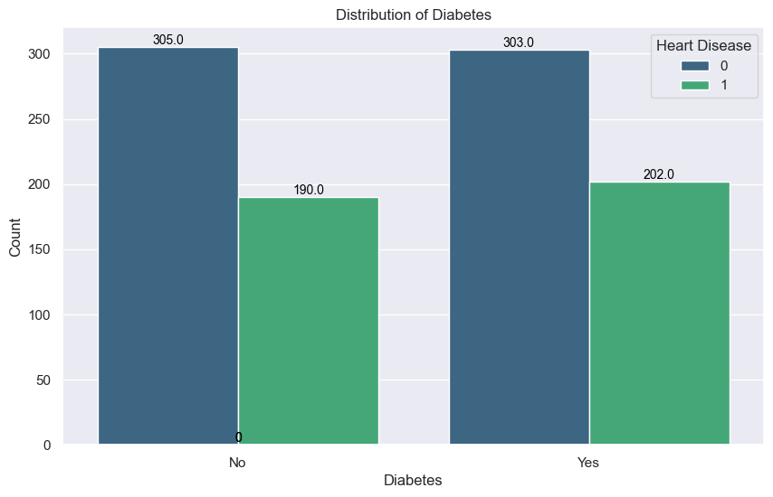

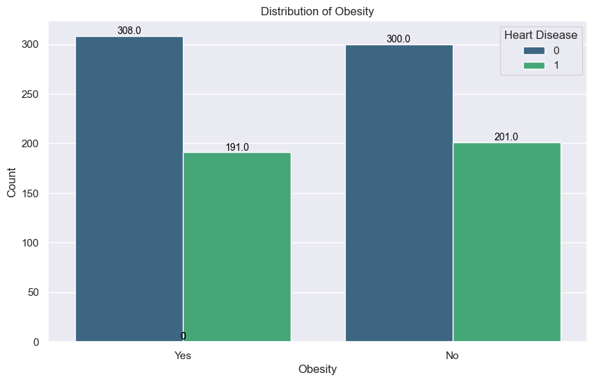

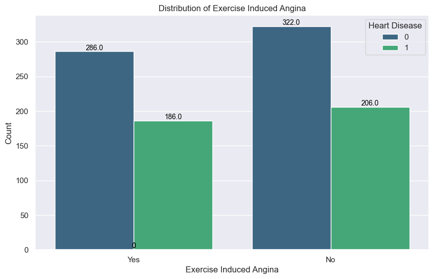

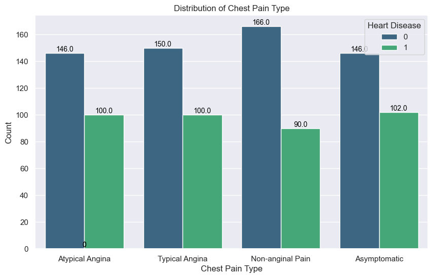

```python
object_columns = df.select_dtypes(include=['object'])

for i in object_columns:
    plt.figure(figsize=(10, 6))


    sns.countplot(x=i, data=df, palette='viridis', hue='Heart Disease')


    for p in plt.gca().patches:
        plt.gca().annotate(f'{p.get_height()}',
                           (p.get_x() + p.get_width() / 2., p.get_height()),
                           ha='center', va='center', fontsize=10, color='black',
                           xytext=(0, 5),
                           textcoords='offset points')


    plt.xlabel(i)
    plt.ylabel('Count')
    plt.title(f'Distribution of {i}')


    plt.show()
```

### Summary Statistics of Categorical Variables:

```python
object_columns = df.select_dtypes(include=['object'])

for i in object_columns:
    print(df[i].value_counts())
    print('**************************')
```

```
Gender
Female    503
Male      497
Name: count, dtype: int64
Smoking
Never      338
Current    336
Former     326
Name: count, dtype: int64
Alcohol Intake
Heavy       346
Moderate    314
Name: count, dtype: int64
Family History
No     501
Yes    499
Name: count, dtype: int64
Diabetes
Yes    505
No     495
Name: count, dtype: int64
Obesity
No     501
Yes    499
Name: count, dtype: int64
Exercise Induced Angina
No     528
Yes    472
Name: count, dtype: int64
Chest Pain Type
Non-anginal Pain    256
Typical Angina      250
Asymptomatic        248
Atypical Angina     246
Name: count, dtype: int64
```

#### These statistics provide an overview of the distribution of each categorical variable in the dataset, which is useful for understanding the data and for further analysis or modeling.

## 1.3 EDA for continuous variables

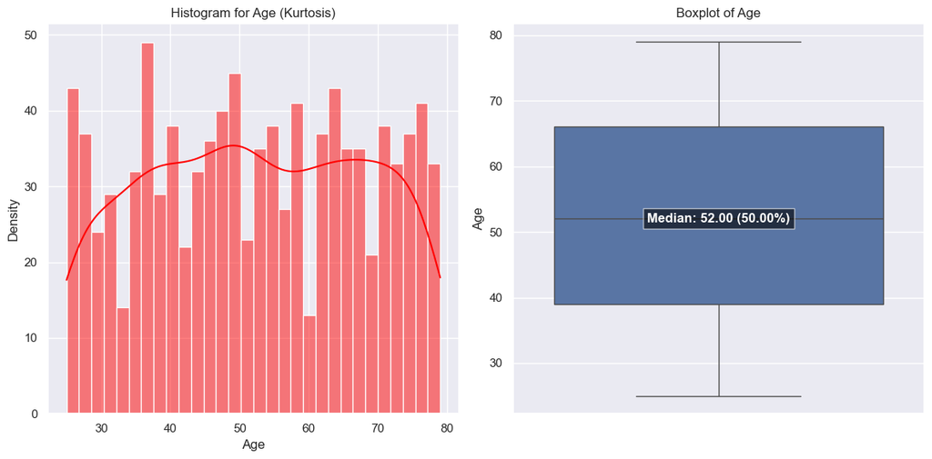

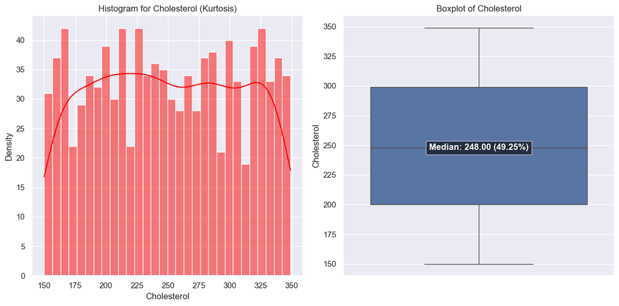

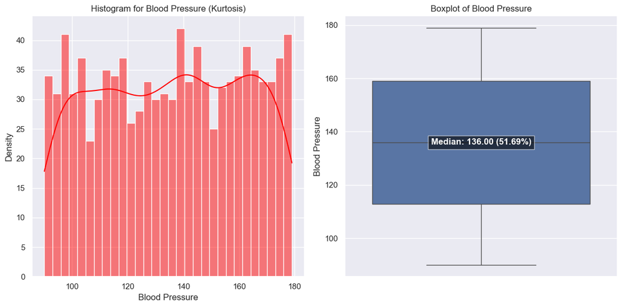

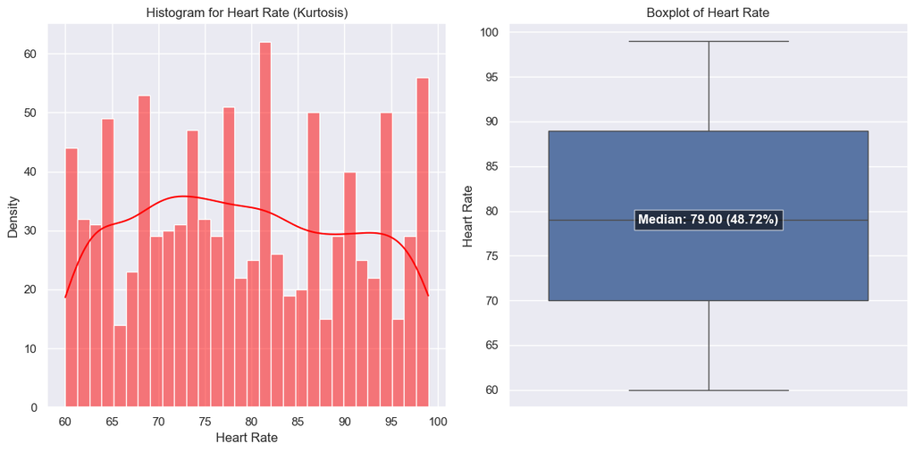

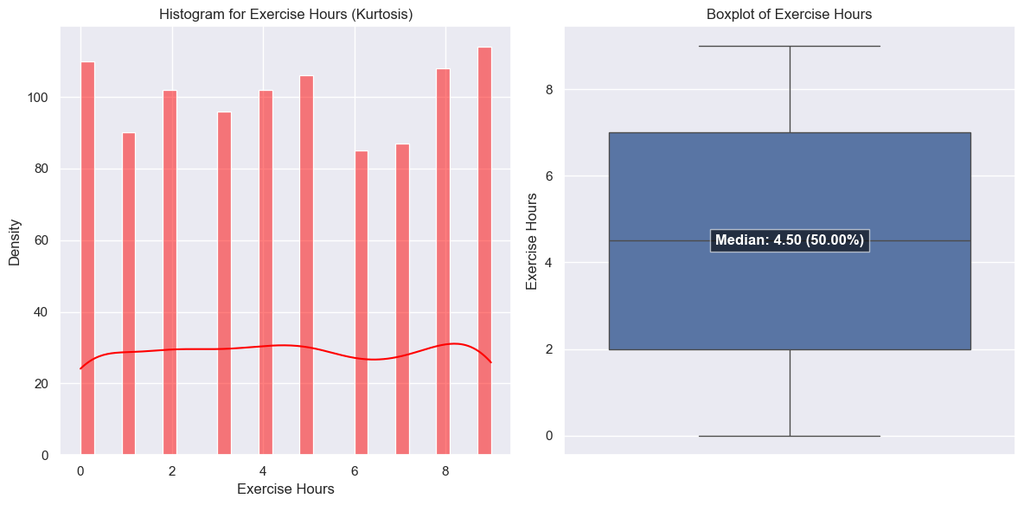

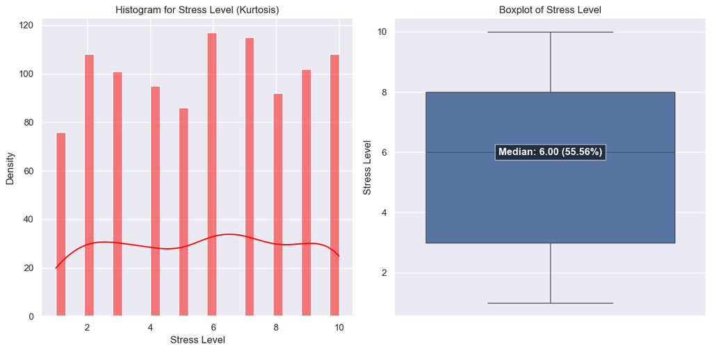

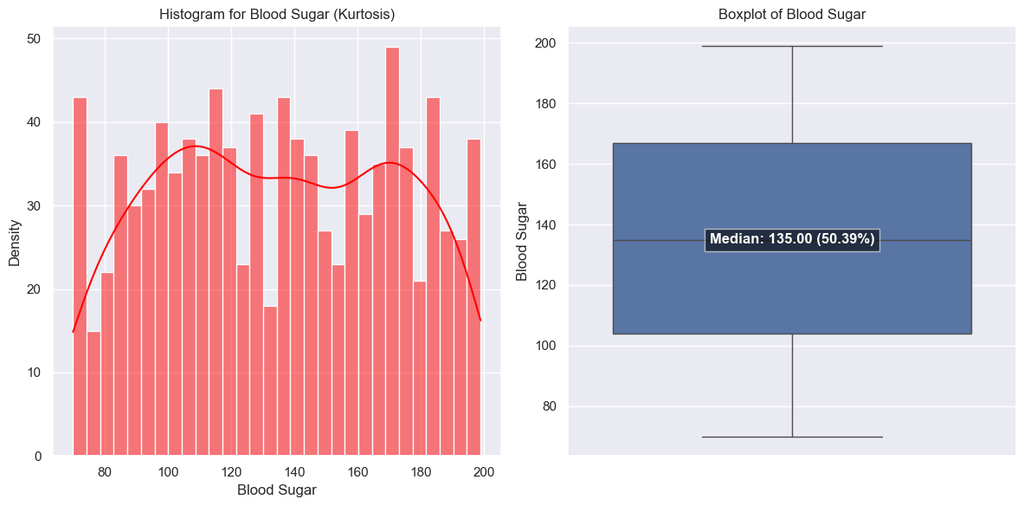

```python
continuous_columns = ['Age', 'Cholesterol', 'Blood Pressure', 'Heart Rate', 'Exercise Hours', 'Stress Level', 'Blood Sugar']

for col in continuous_columns:
    plt.figure(figsize=(12, 6))


    skewness = df[col].skew()
    distribution_type = "Kurtosis" if abs(skewness) < 0.5 else "Skewed"


    plt.subplot(1, 2, 1)
    sns.histplot(df[col], kde=True, color='red', bins=30)
    plt.xlabel(col)
    plt.ylabel('Density')
    plt.title(f'Histogram for {col} ({distribution_type})')

    # Boxplot
    plt.subplot(1, 2, 2)
    sns.boxplot(y=df[col])
    plt.title(f'Boxplot of {col}')


    median = df[col].median()
    median_percentage = (median - df[col].min()) / (df[col].max() - df[col].min()) * 100

    plt.text(0, median, f'Median: {median:.2f} ({median_percentage:.2f}%)',
             horizontalalignment='center',
             verticalalignment='center',
             fontsize=12, color='white', weight='bold',
             bbox=dict(facecolor='black', alpha=0.6))

    # Show the plot
    plt.tight_layout()
    plt.show()
```

### Summary Statistics of Continuous Variables:

```python
df.describe()
```

|  | Age | Cholesterol | Blood Pressure | Heart Rate | Exercise Hours | Stress Level | Blood Sugar | Heart Disease |
| --- | --- | --- | --- | --- | --- | --- | --- | --- |
| count | 1000.000000 | 1000.000000 | 1000.0000 | 1000.000000 | 1000.000000 | 1000.000000 | 1000.000000 | 1000.000000 |
| mean | 52.293000 | 249.939000 | 135.2810 | 79.204000 | 4.529000 | 5.646000 | 134.941000 | 0.392000 |
| std | 15.727126 | 57.914673 | 26.3883 | 11.486092 | 2.934241 | 2.831024 | 36.699624 | 0.488441 |
| min | 25.000000 | 150.000000 | 90.0000 | 60.000000 | 0.000000 | 1.000000 | 70.000000 | 0.000000 |
| 25% | 39.000000 | 200.000000 | 112.7500 | 70.000000 | 2.000000 | 3.000000 | 104.000000 | 0.000000 |
| 50% | 52.000000 | 248.000000 | 136.0000 | 79.000000 | 4.500000 | 6.000000 | 135.000000 | 0.000000 |
| 75% | 66.000000 | 299.000000 | 159.0000 | 89.000000 | 7.000000 | 8.000000 | 167.000000 | 1.000000 |
| max | 79.000000 | 349.000000 | 179.0000 | 99.000000 | 9.000000 | 10.000000 | 199.000000 | 1.000000 |

#### The tabel above showing the summary provides an overview of the central tendency, dispersion, and distribution of each contiuse variable in the dataset.

### Analysis of Skewness in Integer Columns

```python
object_columns = df.select_dtypes(include=['int64'])

for i in object_columns:
    print('skew Value :',df[i].skew())
    print('**************************')
```

```
skew Value : -0.028256736788575463
skew Value : 0.010662176750321276
skew Value : -0.04033191199684379
skew Value : 0.07765243069080488
skew Value : 0.004642194072973924
skew Value : -0.04069262500139927
skew Value : 0.007380741457912805
skew Value : 0.4431095711016623
```

As we can observe, the skewness is mild wish is because the values range between -1 and +1. Therefore, no transformation is required.

### Kurtosis Analysis of Integer Columns :

```python
object_columns = df.select_dtypes(include=['int64'])

for i in object_columns:
    print('kurtosis Value :',df[i].kurtosis())
    print('**************************')
```

```
kurtosis Value : -1.1604102965908354
kurtosis Value : -1.2061442004530984
kurtosis Value : -1.2166610497761403
kurtosis Value : -1.1563896430645286
kurtosis Value : -1.2454034476886355
kurtosis Value : -1.204700146535161
kurtosis Value : -1.1648710587409876
kurtosis Value : -1.8072724641748117
```

The kurtosis values for the integer columns are all negative, indicating that the distributions are platykurtic with lighter tails and flatter peaks compared to a normal distribution. This suggests fewer extreme values and a more evenly distributed data set around the mean

# Machine learning

## 2.1 Remove uninformative columns

```
 We need to remove the 'Alcohol Intake' column from the dataset due to the highest percentage of missing values, which is around 35%.
```

```python
df.drop(['Alcohol Intake'], axis=1, inplace=True)
df.head()
```

|  | Age | Gender | Cholesterol | Blood Pressure | Heart Rate | Smoking | Exercise Hours | Family History | Diabetes | Obesity | Stress Level | Blood Sugar | Exercise Induced Angina | Chest Pain Type | Heart Disease |
| --- | --- | --- | --- | --- | --- | --- | --- | --- | --- | --- | --- | --- | --- | --- | --- |
| 0 | 75 | Female | 228 | 119 | 66 | Current | 1 | No | No | Yes | 8 | 119 | Yes | Atypical Angina | 1 |
| 1 | 48 | Male | 204 | 165 | 62 | Current | 5 | No | No | No | 9 | 70 | Yes | Typical Angina | 0 |
| 2 | 53 | Male | 234 | 91 | 67 | Never | 3 | Yes | No | Yes | 5 | 196 | Yes | Atypical Angina | 1 |
| 3 | 69 | Female | 192 | 90 | 72 | Current | 4 | No | Yes | No | 7 | 107 | Yes | Non-anginal Pain | 0 |
| 4 | 62 | Female | 172 | 163 | 93 | Never | 6 | No | Yes | No | 2 | 183 | Yes | Asymptomatic | 0 |

### 2.2 Encode categorical variables:

We are going to encode 'Gender','Smoking','Family History','Diabetes','Obesity','Exercise Induced Angina','Chest Pain Type'

```python
le = LabelEncoder()
categorical_columns = ['Gender', 'Family History', 'Diabetes', 'Obesity', 'Exercise Induced Angina']
for column in categorical_columns:
    df[column] = le.fit_transform(df[column])


df = pd.get_dummies(df, columns=['Chest Pain Type', 'Smoking'])
```

### 2.3 The dataset must be converted into x (features) and y (labels)

```python
x = df.drop('Heart Disease', axis=1)
y = df['Heart Disease']
```

## 2.4 We need to look for the distripustion fcor the Outcome variable Heart Disease:

```python
y.tail()
```

```
995    1
996    1
997    0
998    1
999    1
Name: Heart Disease, dtype: int64
```

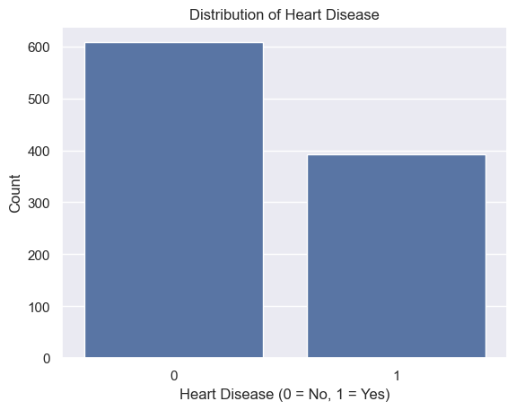

```python
sns.countplot(x=y)
plt.title('Distribution of Heart Disease')
plt.xlabel('Heart Disease (0 = No, 1 = Yes)')
plt.ylabel('Count')
plt.show()
```

The graph shows an imbalanced distribution of the "Heart Disease" variable, with more instances of "no heart disease" (0) than "heart disease" (1).

## 2.5 Split training/testing data (80% training, 20% testing)

Classifiers train on a set of features to predict their corresponding labels.

```python
x_train, x_test, y_train, y_test = train_test_split(x, y, test_size=0.2, random_state=0)
print("Train: " + str(len(y_train)))
print("Test: " + str(len(y_test)))
```

```
Train: 800
Test: 200
```

```python
# Convert training data to a DataFrame if not already
feature_names = [
    'Age',
    'Gender',
    'Cholesterol',
    'Blood Pressure',
    'Heart Rate',
    'Exercise Hours',
    'Family History',
    'Diabetes',
    'Obesity',
    'Stress Level',
    'Blood Sugar',
    'Exercise Induced Angina',
    'Chest Pain Type_Asymptomatic',
    'Chest Pain Type_Atypical Angina',
    'Chest Pain Type_Non-anginal Pain',
    'Chest Pain Type_Typical Angina',
    'Smoking_Current',
    'Smoking_Former',
    'Smoking_Never'
]

x_train_df = pd.DataFrame(x_train, columns=feature_names)
x_test_df = pd.DataFrame(x_test, columns=feature_names)
```

## 2.6 Data Preprocessing:

Scikit-learn has StandardScaler() to convert each variable to zero mean and unit variance.

This is important to make sure classifiers don't weight one variable more than another.

```python
scaler = StandardScaler()

x_train_scaled = scaler.fit_transform(x_train_df )
x_test_scaled = scaler.transform(x_test_df )
```

## 2.7 Model Selection and Training:

```
    The module Im going to be using in this study Logistic Regression, Naive Bayes, SVM, Decision Tree, Random Forest, and a simple Neural Network
```

### 1) Logistic_Regression

```python
## 1) Logistic_Regression
Logistic_Regression = LogisticRegression()
Logistic_Regression.fit(x_train_scaled, y_train)
```

```
LogisticRegression()
```

### 1.2) Test - ROC

```
Probability range: min=2.915652645058951e-05, max=0.9992050859964019
```

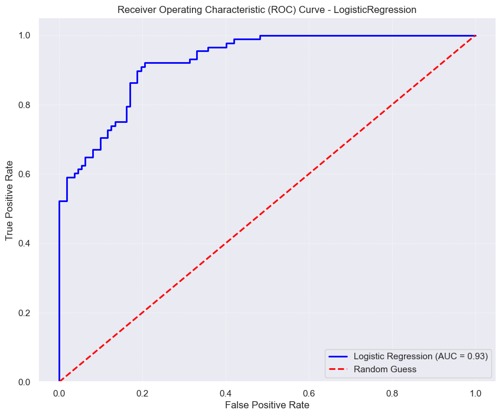

```python
Logistic_probabilities = Logistic_Regression.predict_proba(x_test_scaled)[:, 1]


print(f"Probability range: min={Logistic_probabilities.min()}, max={Logistic_probabilities.max()}")

# Compute ROC curve
fpr, tpr, thresholds = roc_curve(y_test, Logistic_probabilities)

# Plot ROC curve
plt.figure(figsize=(10, 8))
plt.plot(fpr, tpr, color='blue', lw=2, label=f'Logistic Regression (AUC = {roc_auc_score(y_test, Logistic_probabilities):.2f})')
plt.plot([0, 1], [0, 1], color='red', linestyle='--', lw=2, label='Random Guess')
plt.ylim([0.0, 1.05])
plt.xlabel("False Positive Rate")
plt.ylabel("True Positive Rate")
plt.title("Receiver Operating Characteristic (ROC) Curve - LogisticRegression")
plt.legend(loc="lower right")
plt.grid(True, linestyle='--', linewidth=0.5, alpha=0.7)
plt.show()
```

## 1.3)

Test - Confusion Matrix

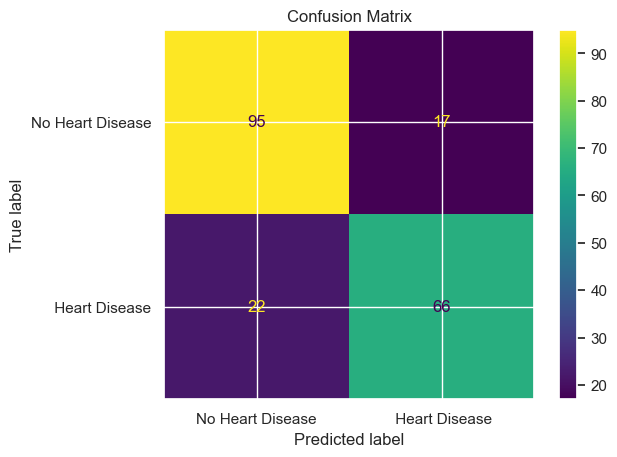

```python
Logistic_predictions = Logistic_Regression.predict(x_test_scaled)
cm = confusion_matrix(y_test, Logistic_predictions)
disp = ConfusionMatrixDisplay(confusion_matrix=cm, display_labels=['No Heart Disease', ' Heart Disease'])
#disp.plot(cmap=plt.cm.Blues)
disp.plot()
plt.title('Confusion Matrix')
plt.show()
```

## 1.4 Test - Classification Report

```python
print(classification_report(y_test, Logistic_predictions))
```

```
              precision    recall  f1-score   support

           0       0.81      0.85      0.83       112
           1       0.80      0.75      0.77        88

    accuracy                           0.81       200
   macro avg       0.80      0.80      0.80       200
weighted avg       0.80      0.81      0.80       200
```

## 2.1) Naive Bayes

```python
## 2) Naive Bayes
Naive_Bayes = GaussianNB()
Naive_Bayes.fit(x_train_scaled, y_train)
```

```
GaussianNB()
```

## 2.2) Test - ROC

```
Probability range: min=1.2968718714346246e-06, max=0.9669642557060514
```

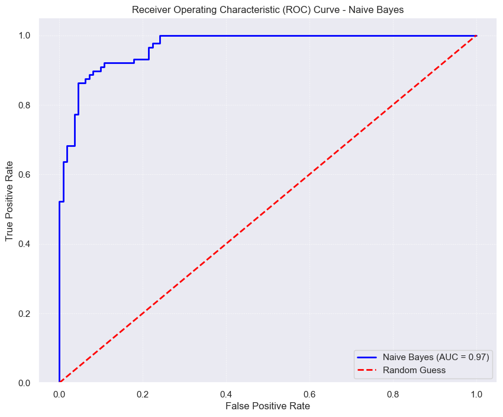

```python
naive_bayes_probabilities = Naive_Bayes.predict_proba(x_test_scaled)[:, 1]


print(f"Probability range: min={naive_bayes_probabilities.min()}, max={naive_bayes_probabilities.max()}")


fpr, tpr, thresholds = roc_curve(y_test, naive_bayes_probabilities)


plt.figure(figsize=(10, 8))
plt.plot(fpr, tpr, color='blue', lw=2, label=f'Naive Bayes (AUC = {roc_auc_score(y_test, naive_bayes_probabilities):.2f})')
plt.plot([0, 1], [0, 1], color='red', linestyle='--', lw=2, label='Random Guess')
plt.xlim([-0.05, 1.05])
plt.ylim([0.0, 1.05])
plt.xlabel("False Positive Rate")
plt.ylabel("True Positive Rate")
plt.title("Receiver Operating Characteristic (ROC) Curve - Naive Bayes")
plt.legend(loc="lower right")
plt.grid(True, linestyle='--', linewidth=0.5, alpha=0.7)
plt.show()
```

## 2.3) Test - Confusion Matrix

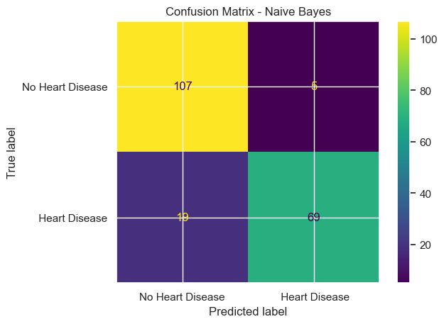

```python
Naive_Bayes_predictions = Naive_Bayes.predict(x_test_scaled)
cm = confusion_matrix(y_test, Naive_Bayes_predictions)
disp = ConfusionMatrixDisplay(confusion_matrix=cm, display_labels=['No Heart Disease', ' Heart Disease'])
#disp.plot(cmap=plt.cm.Blues)
disp.plot()
plt.title('Confusion Matrix - Naive Bayes')
plt.show()
```

## 2.4 Test - Classification Report

```python
print(classification_report(y_test, Naive_Bayes_predictions))
```

```
              precision    recall  f1-score   support

           0       0.85      0.96      0.90       112
           1       0.93      0.78      0.85        88

    accuracy                           0.88       200
   macro avg       0.89      0.87      0.88       200
weighted avg       0.89      0.88      0.88       200
```

## 3.1) SVM

```python
## 3) SVM
SVM_Model1 = SVC(probability=True)
SVM_Model1.fit(x_train_scaled, y_train)
```

```
SVC(probability=True)
```

## 3.2 Compute ROC curve

```
Probability range: min=5.54014857852645e-05, max=0.9999996434311487
```

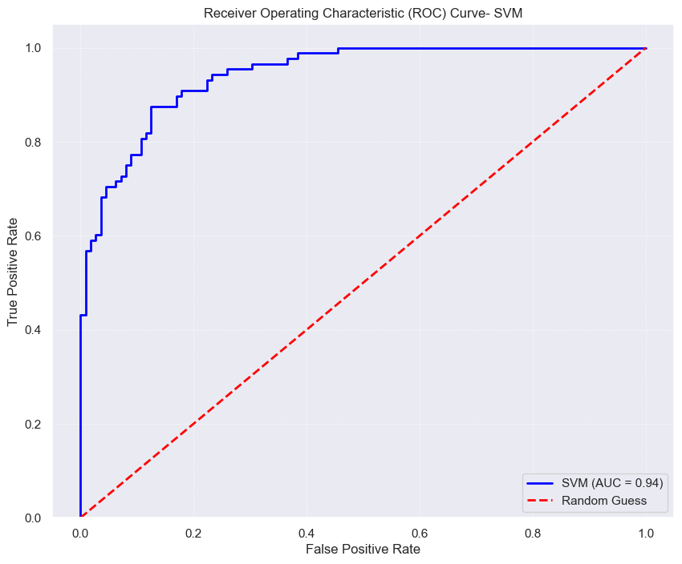

```python
SVM_probabilities = SVM_Model1.predict_proba(x_test_scaled)[:, 1]

# Debug: Check the range of probability values
print(f"Probability range: min={SVM_probabilities.min()}, max={SVM_probabilities.max()}")

# Compute ROC curve
fpr, tpr, thresholds = roc_curve(y_test, SVM_probabilities)

# Plot ROC curve
plt.figure(figsize=(10, 8))
plt.plot(fpr, tpr, color='blue', lw=2, label=f'SVM (AUC = {roc_auc_score(y_test, SVM_probabilities):.2f})')
plt.plot([0, 1], [0, 1], color='red', linestyle='--', lw=2, label='Random Guess')  # Diagonal line for random guessing
plt.xlim([-0.05, 1.05])
plt.ylim([0.0, 1.05])  # Extend y-axis slightly above 1.0 for better view of curve
plt.xlabel("False Positive Rate")
plt.ylabel("True Positive Rate")
plt.title("Receiver Operating Characteristic (ROC) Curve- SVM")
plt.legend(loc="lower right")
plt.grid(True, linestyle='--', linewidth=0.5, alpha=0.7)  # Add grid with lighter style for clarity
plt.show()
```

## 3.3) Test - Confusion Matrix

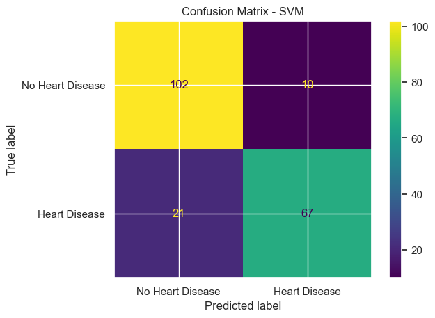

```python
svm_predictions = SVM_Model1.predict(x_test_scaled)

# Compute confusion matrix
cm = confusion_matrix(y_test, svm_predictions)

# Display the confusion matrix
disp = ConfusionMatrixDisplay(confusion_matrix=cm, display_labels=['No Heart Disease', 'Heart Disease'])
disp.plot()
plt.title('Confusion Matrix - SVM')
plt.show()
```

## 3.4 Test - Classification Report

```python
print(classification_report(y_test, svm_predictions))
```

```
              precision    recall  f1-score   support

           0       0.83      0.91      0.87       112
           1       0.87      0.76      0.81        88

    accuracy                           0.84       200
   macro avg       0.85      0.84      0.84       200
weighted avg       0.85      0.84      0.84       200
```

## 4.1) Decision Tree

```python
## 4) Decision Tree
Decision_Tree = DecisionTreeClassifier()
Decision_Tree.fit(x_train_scaled, y_train)
```

```
DecisionTreeClassifier()
```

## 4.2 Compute ROC curve

```
Probability range: min=0.0, max=1.0
```

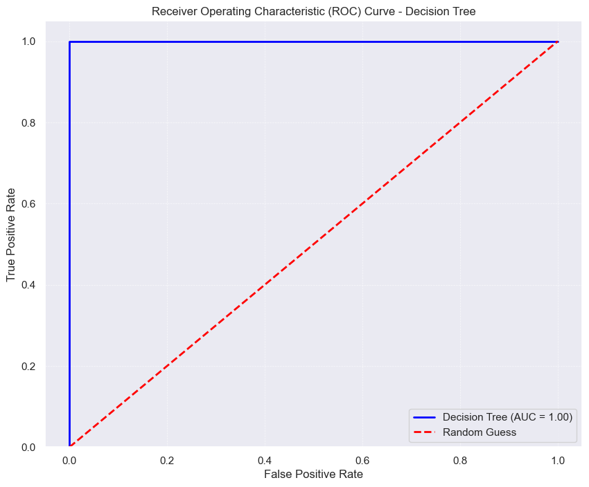

```python
Decision_Tree_probabilities = Decision_Tree.predict_proba(x_test_scaled)[:, 1]


print(f"Probability range: min={Decision_Tree_probabilities.min()}, max={Decision_Tree_probabilities.max()}")


fpr, tpr, thresholds = roc_curve(y_test, Decision_Tree_probabilities)


plt.figure(figsize=(10, 8))
plt.plot(fpr, tpr, color='blue', lw=2, label=f'Decision Tree (AUC = {roc_auc_score(y_test,Decision_Tree_probabilities):.2f})')
plt.plot([0, 1], [0, 1], color='red', linestyle='--', lw=2, label='Random Guess')
plt.xlim([-0.05, 1.05])
plt.ylim([0.0, 1.05])
plt.xlabel("False Positive Rate")
plt.ylabel("True Positive Rate")
plt.title("Receiver Operating Characteristic (ROC) Curve - Decision Tree")
plt.legend(loc="lower right")
plt.grid(True, linestyle='--', linewidth=0.5, alpha=0.7)
plt.show()
```

## 4.3) Test - Confusion Matrix

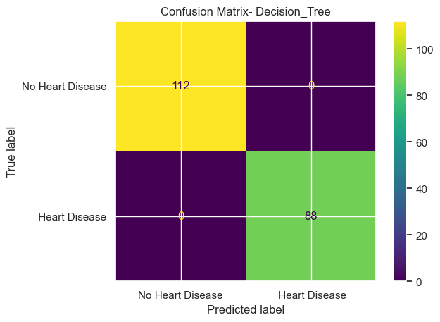

```python
Decision_Tree_predictions = Decision_Tree.predict(x_test_scaled)
cm = confusion_matrix(y_test, Decision_Tree_predictions)
disp = ConfusionMatrixDisplay(confusion_matrix=cm, display_labels=['No Heart Disease', ' Heart Disease'])
#disp.plot(cmap=plt.cm.Blues)
disp.plot()
plt.title('Confusion Matrix- Decision_Tree')
plt.show()
```

### 4.4 Test - Classification Report

```python
print(classification_report(y_test, Decision_Tree_probabilities))
```

```
              precision    recall  f1-score   support

           0       1.00      1.00      1.00       112
           1       1.00      1.00      1.00        88

    accuracy                           1.00       200
   macro avg       1.00      1.00      1.00       200
weighted avg       1.00      1.00      1.00       200
```

### 5.1) Random Forest

```python
## 5) Random Forest
Random_Forest = RandomForestClassifier()
Random_Forest.fit(x_train_scaled, y_train)
```

```
RandomForestClassifier()
```

### 5.2 Compute ROC curve

```
Probability range: min=0.0, max=0.97
```

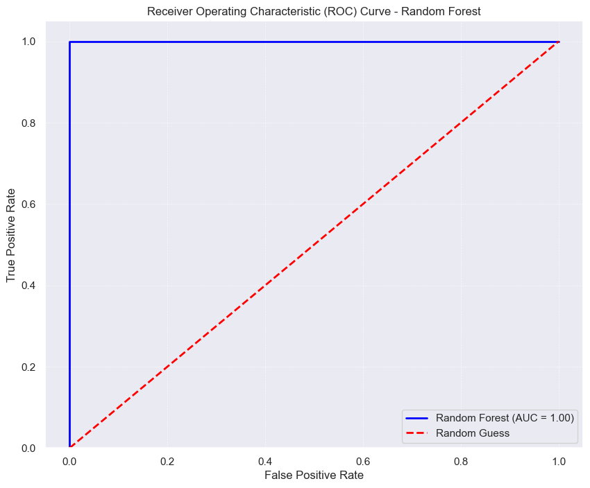

```python
Random_Forest_probabilities = Random_Forest.predict_proba(x_test_scaled)[:, 1]

# Debug: Check the range of probability values
print(f"Probability range: min={Random_Forest_probabilities.min()}, max={Random_Forest_probabilities.max()}")
# Compute ROC curve
fpr, tpr, thresholds = roc_curve(y_test, Random_Forest_probabilities)

# Plot ROC curve
plt.figure(figsize=(10, 8))
plt.plot(fpr, tpr, color='blue', lw=2, label=f'Random Forest (AUC = {roc_auc_score(y_test, Random_Forest_probabilities):.2f})')
plt.plot([0, 1], [0, 1], color='red', linestyle='--', lw=2, label='Random Guess')  # Diagonal line for random guessing
plt.xlim([-0.05, 1.05])
plt.ylim([0.0, 1.05])  # Extend y-axis slightly above 1.0 for better view of curve
plt.xlabel("False Positive Rate")
plt.ylabel("True Positive Rate")
plt.title("Receiver Operating Characteristic (ROC) Curve - Random Forest")
plt.legend(loc="lower right")
plt.grid(True, linestyle='--', linewidth=0.5, alpha=0.7)  # Add grid with lighter style for clarity
plt.show()
```

### 5.3) Test - Confusion Matrix

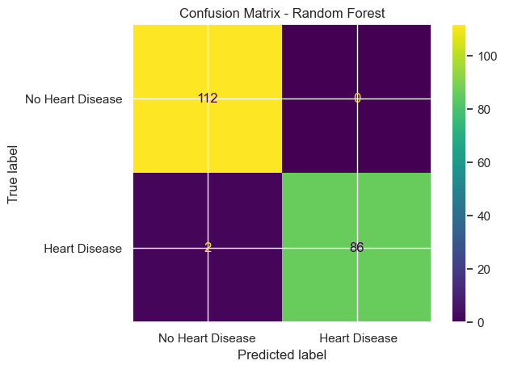

```python
Random_Fores_predictions = Random_Forest.predict(x_test_scaled)
cm = confusion_matrix(y_test, Random_Fores_predictions)
disp = ConfusionMatrixDisplay(confusion_matrix=cm, display_labels=['No Heart Disease', ' Heart Disease'])
#disp.plot(cmap=plt.cm.Blues)
disp.plot()
plt.title('Confusion Matrix - Random Forest')
plt.show()
```

### 2.4 Test - Classification Report

```python
print(classification_report(y_test, Random_Fores_predictions))
```

```
              precision    recall  f1-score   support

           0       0.98      1.00      0.99       112
           1       1.00      0.98      0.99        88

    accuracy                           0.99       200
   macro avg       0.99      0.99      0.99       200
weighted avg       0.99      0.99      0.99       200
```

## 6.1) Neural Network:

```python
## 6) Neural Network:
Neural_Network = MLPClassifier(max_iter=1000)
Neural_Network.fit(x_train_scaled, y_train)
```

```
MLPClassifier(max_iter=1000)
```

### 6.2 Compute ROC curve

```
Probability range: min=6.940634570123246e-10, max=0.9999999952571317
```

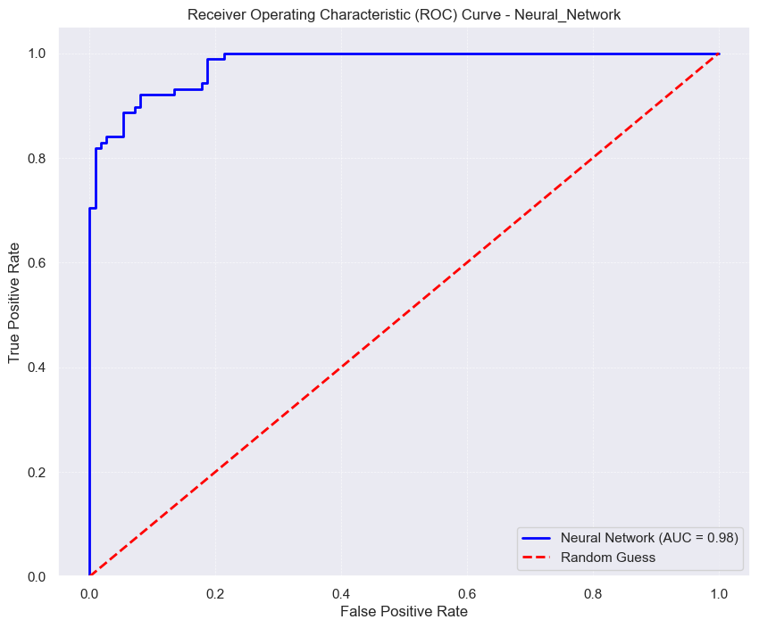

```python
Neural_Network_probabilities = Neural_Network.predict_proba(x_test_scaled)[:, 1]


print(f"Probability range: min={Neural_Network_probabilities.min()}, max={Neural_Network_probabilities.max()}")


fpr, tpr, thresholds = roc_curve(y_test, Neural_Network_probabilities)


plt.figure(figsize=(10, 8))
plt.plot(fpr, tpr, color='blue', lw=2, label=f'Neural Network (AUC = {roc_auc_score(y_test, Neural_Network_probabilities):.2f})')
plt.plot([0, 1], [0, 1], color='red', linestyle='--', lw=2, label='Random Guess')
plt.xlim([-0.05, 1.05])
plt.ylim([0.0, 1.05])
plt.xlabel("False Positive Rate")
plt.ylabel("True Positive Rate")
plt.title("Receiver Operating Characteristic (ROC) Curve - Neural_Network")
plt.legend(loc="lower right")
plt.grid(True, linestyle='--', linewidth=0.5, alpha=0.7)
plt.show()
```

### 6.3 Test - Confusion Matrix

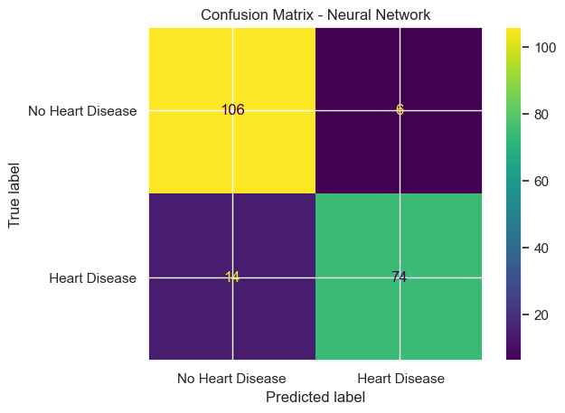

```python
Neural_Network_predictions = Neural_Network.predict(x_test_scaled)
cm = confusion_matrix(y_test, Neural_Network_predictions)
disp = ConfusionMatrixDisplay(confusion_matrix=cm, display_labels=['No Heart Disease', ' Heart Disease'])
#disp.plot(cmap=plt.cm.Blues)
disp.plot()
plt.title('Confusion Matrix - Neural Network')
plt.show()
```

### 6.4 Test - Classification Report

```python
print(classification_report(y_test, Neural_Network_predictions))
```

```
              precision    recall  f1-score   support

           0       0.88      0.95      0.91       112
           1       0.93      0.84      0.88        88

    accuracy                           0.90       200
   macro avg       0.90      0.89      0.90       200
weighted avg       0.90      0.90      0.90       200
```

## Plotting All AUCs Together in One Graph

```python
models = {
    'Logistic Regression': LogisticRegression(),
    'Naive Bayes': GaussianNB(),
    'SVM': SVC(probability=True),
    'Decision Tree': DecisionTreeClassifier(),
    'Random Forest': RandomForestClassifier(),
    'Neural Network': MLPClassifier(max_iter=1000)
}
```

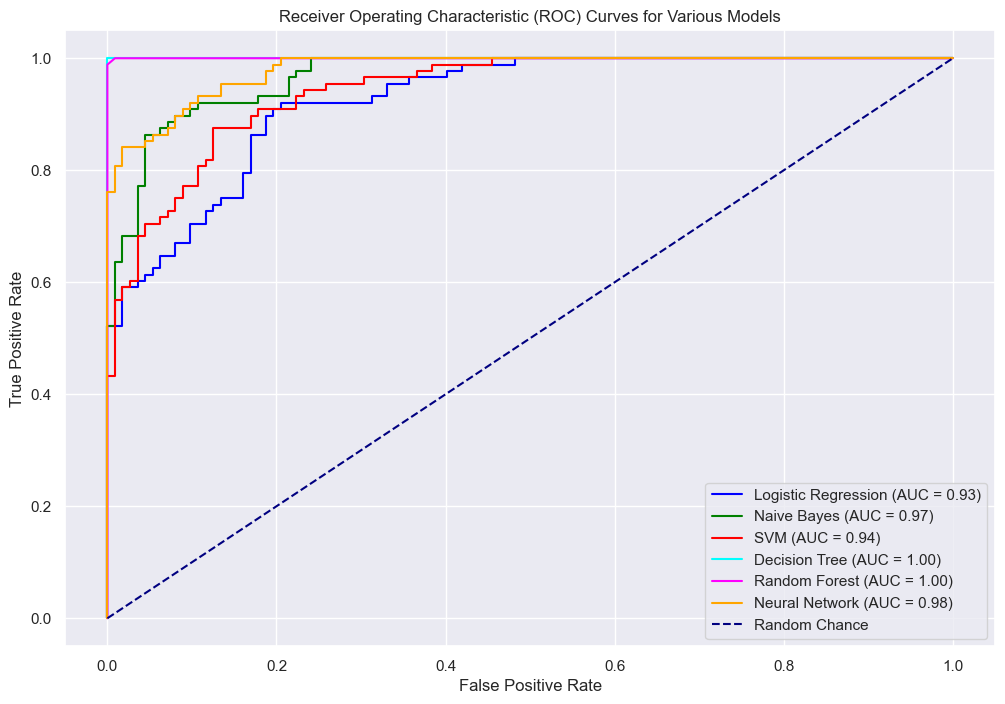

```python
plt.figure(figsize=(12, 8))
colors = ['blue', 'green', 'red', 'cyan', 'magenta', 'orange']

for (model_name, model), color in zip(models.items(), colors):
    model.fit(x_train_scaled, y_train)
    y_pred_prob = model.predict_proba(x_test_scaled)[:, 1]
    fpr, tpr, _ = roc_curve(y_test, y_pred_prob)
    roc_auc = auc(fpr, tpr)
    plt.plot(fpr, tpr, color=color, label=f'{model_name} (AUC = {roc_auc:.2f})')

# Plot the random chance line
plt.plot([0, 1], [0, 1], color='navy', linestyle='--', label='Random Chance')

# Add plot details
plt.xlabel('False Positive Rate')
plt.ylabel('True Positive Rate')
plt.title('Receiver Operating Characteristic (ROC) Curves for Various Models')
plt.legend(loc='lower right')
plt.grid(True)
plt.show()
```

## The ROC curves show that Random Forest and Decision Tree models achieved perfect classification with an AUC of 1.00, indicating potential overfitting, while Neural Network and Naive Bayes also performed strongly with AUCs of 0.98 and 0.97, respectively, demonstrating robust classification capabilities. Logistic Regression and SVM showed solid performance with AUCs of 0.93 and 0.94, respectively, but were slightly less effective compared to other models.

## Ploting the Left curve for all Modules:

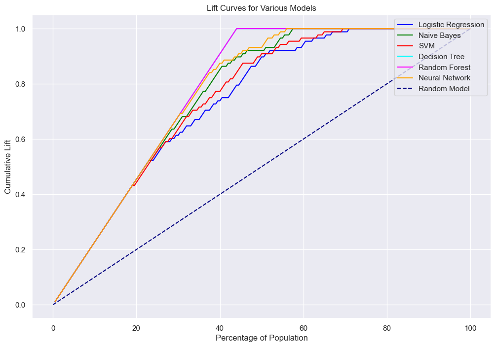

```python
plt.figure(figsize=(12, 8))
colors = ['blue', 'green', 'red', 'cyan', 'magenta', 'orange']

for (model_name, model), color in zip(models.items(), colors):
    model.fit(x_train_scaled, y_train)
    y_pred_prob = model.predict_proba(x_test_scaled)[:, 1]

    # Sort the probabilities and true labels based on probabilities
    sorted_indices = np.argsort(y_pred_prob)[::-1]
    sorted_true_labels = np.array(y_test)[sorted_indices]

    # Calculate cumulative gains
    total_positives = np.sum(y_test)
    cumulative_positives = np.cumsum(sorted_true_labels)
    cumulative_lift = cumulative_positives / total_positives


    population_percentage = np.arange(1, len(y_test) + 1) / len(y_test) * 100


    plt.plot(population_percentage, cumulative_lift, color=color, label=f'{model_name}')


plt.plot([0, 100], [0, 1], color='navy', linestyle='--', label='Random Model')

# Add plot details
plt.xlabel('Percentage of Population')
plt.ylabel('Cumulative Lift')
plt.title('Lift Curves for Various Models')
plt.legend(loc='upper right')
plt.grid(True)
plt.show()
```

## Performs a permutation test for the difference in AUCs

```python
def permutation_auc_test(y_test, Random_Forest_probabilities, Neural_Network_probabilities, n_permutations=1000):
    """Performs a permutation test for the difference in AUCs."""
    observed_auc1 = roc_auc_score(y_test, Random_Forest_probabilities)
    observed_auc2 = roc_auc_score(y_test, Neural_Network_probabilities)
    observed_difference = observed_auc1 - observed_auc2

    permuted_differences = []

    for i in range(n_permutations):

        permuted_labels = np.random.permutation(y_test)


        auc1 = roc_auc_score(permuted_labels, Random_Forest_probabilities)
        auc2 = roc_auc_score(permuted_labels, Neural_Network_probabilities)


        permuted_differences.append(auc1 - auc2)


    p_value = np.mean(np.abs(permuted_differences) >= np.abs(observed_difference))

    return observed_difference, p_value


observed_diff, p_value = permutation_auc_test(y_test, Random_Forest_probabilities, Neural_Network_probabilities)

print(f'Observed difference in AUCs: {observed_diff:.3f}')
print(f'Permutation test p-value: {p_value:.4f}')

if p_value < 0.05:
    print("The difference between the AUCs is statistically significant.")
else:
    print("The difference between the AUCs is not statistically significant.")
```

```
Observed difference in AUCs: 0.021
Permutation test p-value: 0.3700
The difference between the AUCs is not statistically significant.
```

## Statistical comparison between ROC-AUC between the best 2 classifiers

### Next step is to compare these 2 classifiers in terms of confusion matrix and classification table to see which model fits best with intended clinical use

```python
## NN
print("----------------- Neural Network ----------------------")
print(classification_report(y_test, Neural_Network_predictions))
print("----------------- Random Fores ----------------------")
## RF
print(classification_report(y_test, Random_Fores_predictions))
```

```
----------------- Neural Network ----------------------
              precision    recall  f1-score   support

           0       0.88      0.95      0.91       112
           1       0.93      0.84      0.88        88

    accuracy                           0.90       200
   macro avg       0.90      0.89      0.90       200
weighted avg       0.90      0.90      0.90       200

----------------- Random Fores ----------------------
              precision    recall  f1-score   support

           0       0.98      1.00      0.99       112
           1       1.00      0.98      0.99        88

    accuracy                           0.99       200
   macro avg       0.99      0.99      0.99       200
weighted avg       0.99      0.99      0.99       200
```

## Can we accurately predict risk of heart attack using patients' demographics, comorbidities, and other life style factors?

The answer:

Yes, we can accurately predict the risk of a heart attack using patients' demographics, comorbidities, and lifestyle factors. The analysis shows that these variables, when used in conjunction with robust machine learning models, provide a reliable basis for assessing heart attack risk, thus supporting clinical decision-making and potentially improving patient outcomes.